# Notebook 02 – Solutions

## Getting Started

Before running this notebook, select “Session > Restart R and Clear Output” in the menu above to start a new R session. This will clear any old data sets and give us a blank slate to start with.

After starting a new session, run the following code chunk to load the libraries and data that we will be working with today.

I have set the options `include=FALSE` and `message=FALSE` to avoid cluttering the solutions with all the output from this code.

## Grammar of Graphics

### Elements

Data visualization is an incredibly important skill and a task that R is particularly well-designed for. We are going to learn and use the **ggplot2** package for building beautiful and informative graphics. The package makes it easy to build fairly complex graphics in a way that is guided by a general theory of data visualization. The only downside is that, because it is built around a theoretical model rather than many one-off solutions for different tasks, it has a steep initial learning curve. These notes will, hopefully, make this as painless as possible.

The core idea of the grammar of graphics is that visualizations are composed of independent *layers*. To describe a specific layer, we need to specify several elements:

- *data*: the data set from which data will be taken to construct the plot
- *geom*: a description of what kinds of objects to plot (i.e., points, labels, or boxes)
- *aes*: a mapping from elements of the plot to columns in our data set (i.e., the position on the x-axis or the color of our points); it stands for aesthetics

You can describe virtually any type of visualization by putting together these elements.

To show how to use the grammar of graphics, we will start by using the food data set introduced in the previous notes, with each row describing a particular item of food along with various nutritional information. The first plot we will make is a scatter plot that investigates the relationship between calories and the total fat (in grams) that are in a 100g portion of each food item. In the language of the grammar of graphics we can describe this with the following elements:

- *data*: our data set is called `food`
- *geom*: we will build a plot with a points geometry; each row of data is represented by a point
- *aes*: the x-axis will be associated with `calories` and the y-axis with `total_fat`

### Scatter plot example

The easiest way to understand how we specify these elements within **ggplot** is by seeing an example. Here is the code to specify the data, geom, and aes:

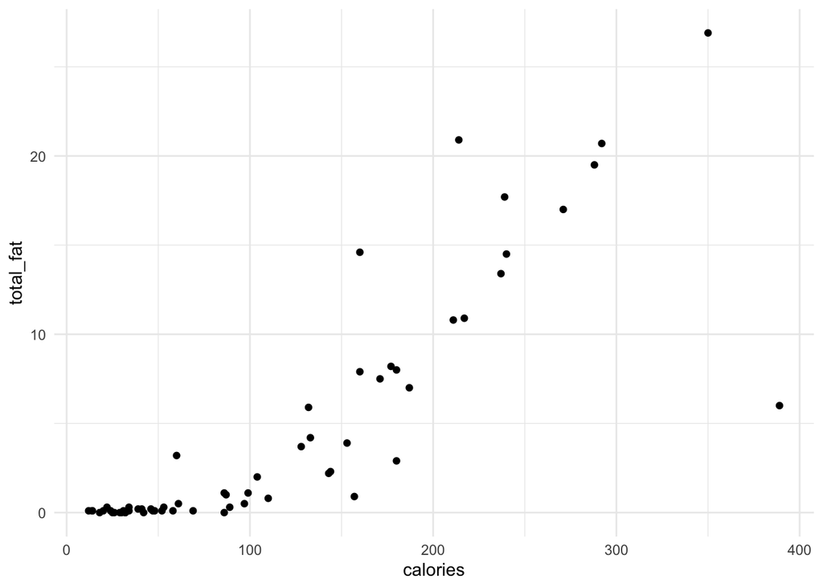

```r
food %>%
  ggplot() +
    geom_point(aes(x = calories, y = total_fat))
```

In the first line we specify the data set (`food`), which is then piped (`%>%`) into the function `ggplot`, which instructs R to start a new plot. Next, we add (`+`) a layer to the plot. This layer uses a points geom (`geom_point`) and describes two aes values, `x = calories` and `y = total_fat`.

In order to make a similar plot with different variables, or a different data set, you can copy this code and change the associated variable names (`food`, `calories`, and `total_fat`). In the code below create another scatterplot from the food data set, choosing any two variables for the two axes:

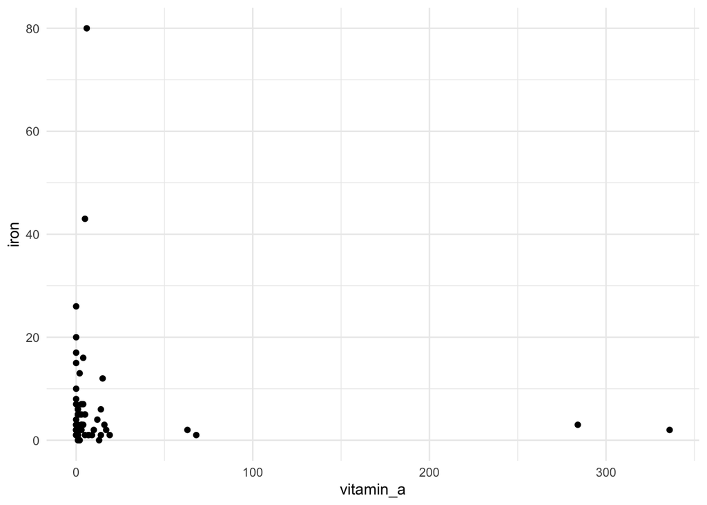

```r
food %>%
  ggplot() +
    geom_point(aes(x = vitamin_a, y = iron))
```

In the next few classes we will see how to modify and build on this basic structure to create more complex graphics.

### Text Geometries

Let’s go through several other choices of geometries that we could have in the plot. There are many of these, but in general you can create most plots with only a small number of geometry types. To start, we will use the geometry `geom_text`, which puts a small label in place of the points in our previous example.

The text geometry needs an additional aes called `label` to describe what variable in the data set should be used as the label. Here, we use the variable called `item` to label each point with the name of the specific food item in question (the column is called `item`):

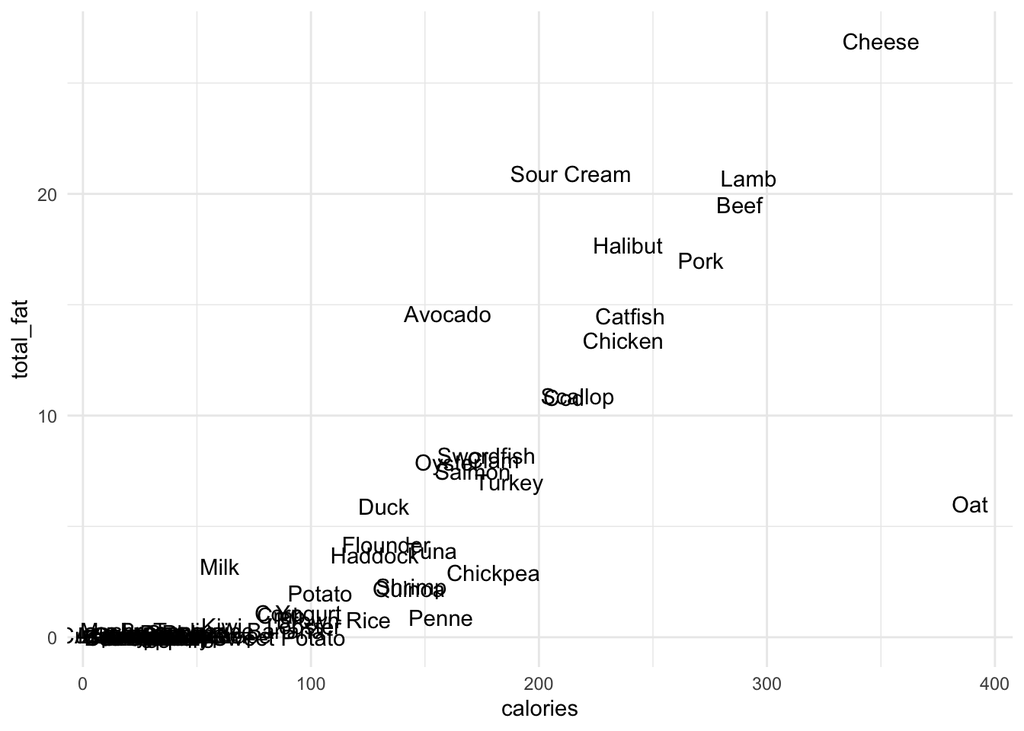

```r
food %>%
  ggplot() +
    geom_text(aes(x = calories, y = total_fat, label = item))
```

Can you now identify what food has the highest amount of fat? Or the highest calorie count? Hopefully!

You likely cannot, however, figure out what foods have the lowest amount of fat because the labels become too clumped together. In order to try to address this issue, we can use a slightly different geometry called `geom_text_repel`. It also places labels on the plot, but has logic that avoids intersecting labels. Instead, labels are moved away from the data points and connected (when needed) by a line segment:

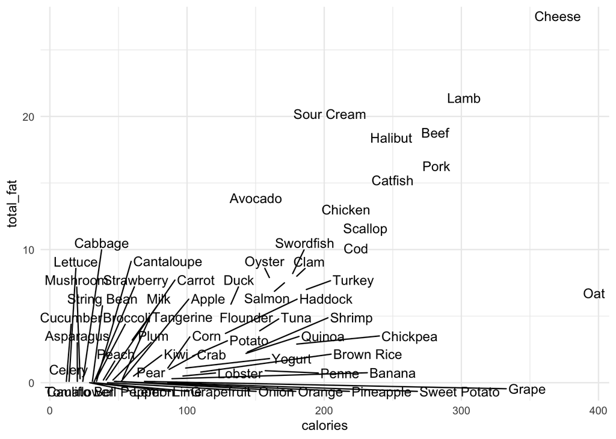

```r
food %>%
  ggplot() +
    geom_text_repel(aes(x = calories, y = total_fat, label = item))
```

This is still a bit busy in the lower left-hand corner, but should be slightly easier to read in the middle of the plot.

We can make the plot a bit more readable by adding two *layers*, one with the text and another with the points. To do this, just add the two geometries together like this:

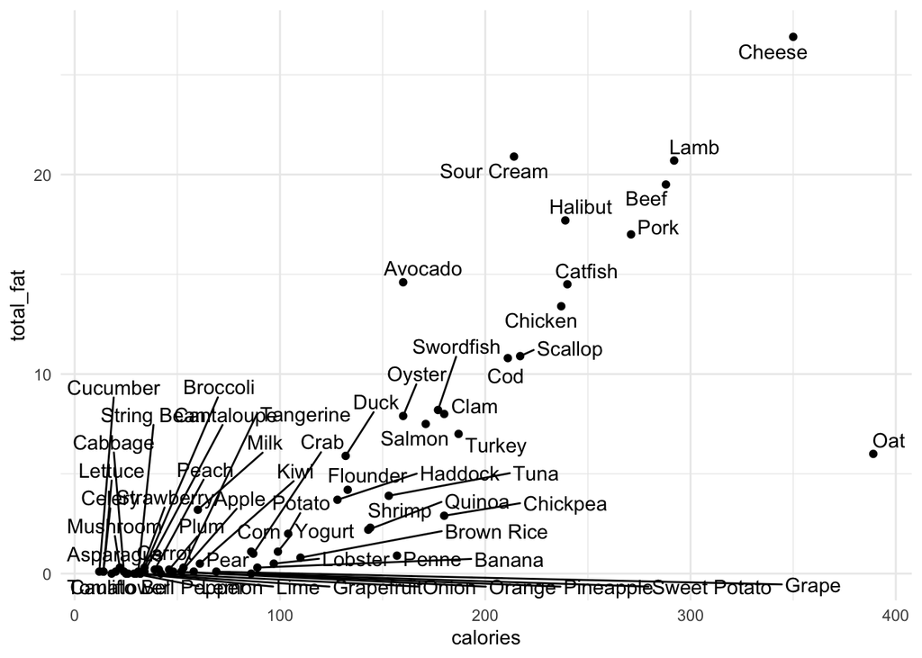

```r
food %>%
  ggplot() +
    geom_text_repel(aes(x = calories, y = total_fat, label = item)) +
    geom_point(aes(x = calories, y = total_fat))
```

Next class we will see how to further improve this plot.

### Formatting code

- indent every line that follows a pipe with two extra spaces
- indent every line below `ggplot` by an additional two spaces (four total)

As with our original set of style guidelines, you will make your life a lot easier if you get used to these rules right from the start. Note that hitting TAB should give you two spaces in the RStudio Cloud editor.

## Practice

### Cities Data

To further practice the Grammar of Graphics, we will work with the largest cities data set.

```r
cities <- read_csv(file.path("data", "largest_cities.csv"))
cities
```

```
## # A tibble: 81 x 26
##    name  country city_definition population city_pop city_area metro_pop
##    <chr> <chr>   <chr>                <dbl>    <dbl>     <dbl>     <dbl>
##  1 Tokyo Japan   Metropolis pre…       37.4    13.5       2191      37.3
##  2 Delhi India   National capit…       28.5    16.8       1484      29
##  3 Shan… China   Municipality          25.6    24.2       6341      NA
##  4 São … Brazil  Municipality          21.6    12.3       1521      21.7
##  5 Mexi… Mexico  City-state            21.6     8.92      1485      20.9
##  6 Cairo Egypt   Urban governor…       20.1     9.5       3085      NA
##  7 Mumb… India   Municipality          20.0    12.5        603      24.4
##  8 Beij… China   Municipality          19.6    21.7      16411      NA
##  9 Dhaka Bangla… Capital city          19.6    14.4        338      14.5
## 10 Osaka Japan   Designated city       19.3     2.72       225      19.3
## # … with 71 more rows, and 19 more variables: metro_area <dbl>,
## #   urban_pop <dbl>, urban_area <dbl>, wiki <chr>, country_code2 <chr>,
## #   country_code3 <chr>, country_name_official <chr>, continent <chr>,
## #   lon <dbl>, lat <dbl>, koppen_code <chr>, koppen_main <chr>, city <chr>,
## #   num <dbl>, cost_of_living <dbl>, cost_rent <dbl>, cost_groceries <dbl>,
## #   cost_restaurant <dbl>, local_pp <dbl>
```

Population numbers are given in millions and areas are given in square kilometers. The three different kinds of populations refer to different ways of describing what is included in a city. The variable `population` is a measurement from the UN (2018) that tries to consistently define the region of a city. More information is available in the U.N.’s World Urbanization Prospectus, which is available [here](https://population.un.org/wup/Publications/Files/WUP2018-Highlights.pdf). The other three measurements refer to:

- **city**: city proper, defined by local administrative boundaries
- **metro**: according to UNICEF, the Metro Region is an area “comprising the urban area as a whole and its primary commuter areas… In addition to the city proper, a metropolitan area includes both the surrounding territory with urban levels of residential density and some additional lower-density areas that are adjacent to and linked to the city.” See [UNICEF](https://www.unicef.org/sowc2012/statistics.php) for more information.
- **urban**: an area that consists of a “continuously built up land mass of urban development that is within a labor market (metropolitan area or metropolitan region) and contains no rural land”.

Several of the questions in this and the following notebooks concern the analysis of the relationship between these various definitions.

### Scatterplot

In the code below, write the code to produce a scatter plot with population on the x-axis and the city population on the y-axis. I have set `warning=FALSE` because there are some missing data values and it will be helpful to turn off the warnings about these data rows.

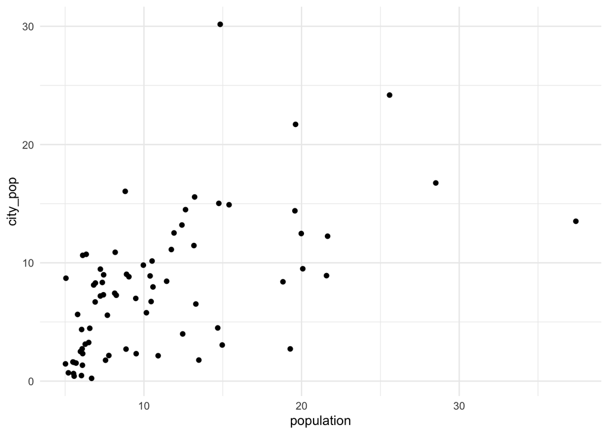

```r
cities %>%
  ggplot() +
    geom_point(aes(x = population, y = city_pop))
```

Now, in the code region below, produce a scatter plot with population on the x-axis and metro population on the y-axis.

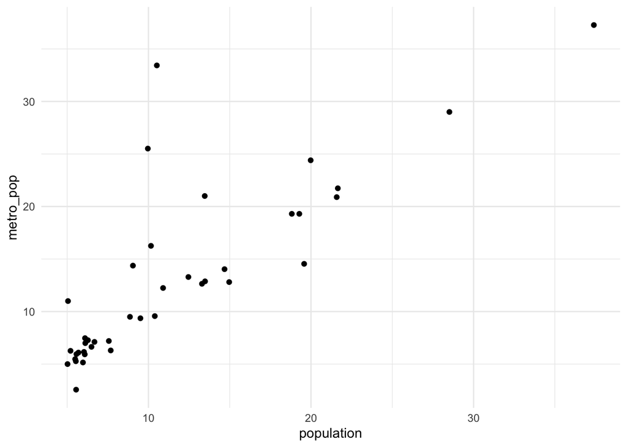

```r
cities %>%
  ggplot() +
    geom_point(aes(x = population, y = metro_pop))
```

Which of the two regional populations (metro or city) seem to more closely relate to the U.N.’s definition of a cities population (e.g., the `population` variable). **Answer**: The metropolitan population is much closer to the UN definition than the city population variable.

## Text Plot

Produce a plot with population on the x-axis and metro population on the y-axis and label each point with the city name.

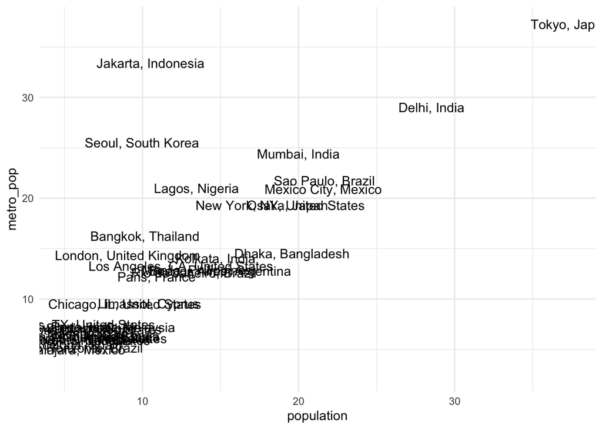

```r
cities %>%
  ggplot() +
    geom_text(aes(x = population, y = metro_pop, label = city))
```

What two cities seem to have the largest (absolute) discrepancy between their UN population and the metro population? **Answer**: Jakarta and Seoul seem to stand out the most (their metro populations are much larger than the offical UN population numbers).

Produce a plot with a text geometry where longitude (`lon`) is on the x-axis, latitude is on the y-axis (`lat`), and the labels are given by the city names (`name`).

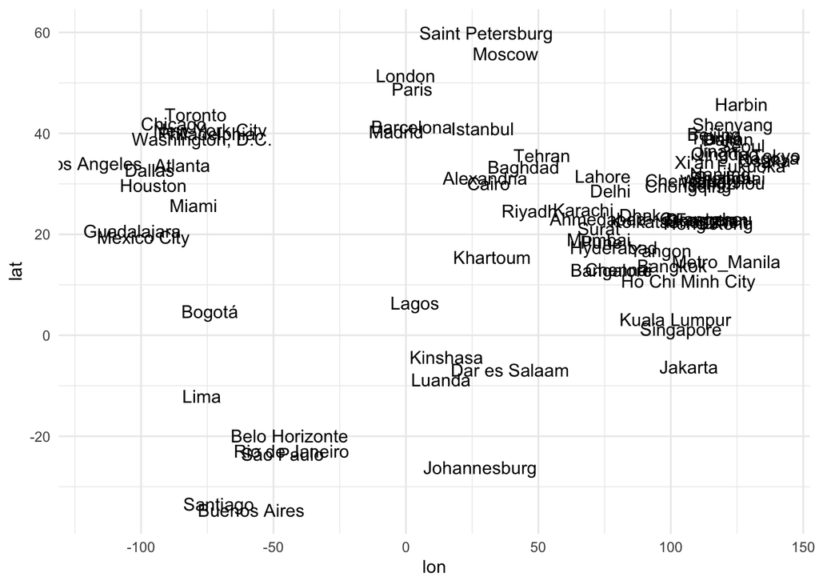

```r
cities %>%
  ggplot() +
    geom_text(aes(x = lon, y = lat, label = name))
```

This should roughly resemble a map of the world. In the code below, produce a modified version of this plot, replacing the text layer with two layers: a text repel layer and well as a point layer.

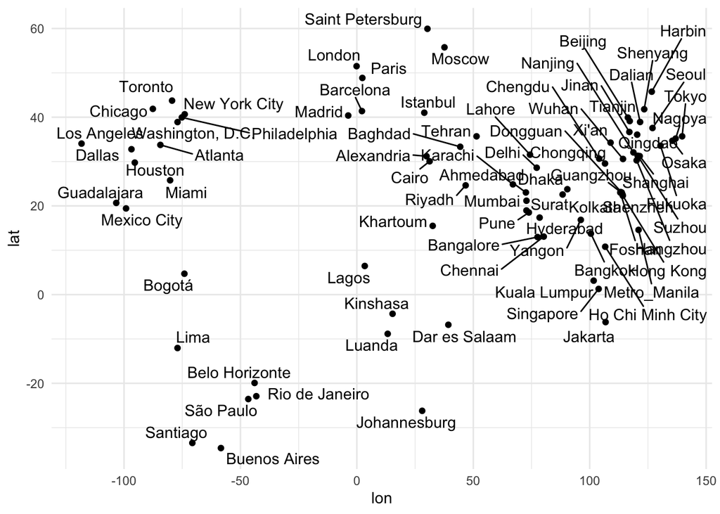

```r
cities %>%
  ggplot() +
    geom_text_repel(aes(x = lon, y = lat, label = name)) +
    geom_point(aes(x = lon, y = lat))
```

Which of these two plots do you find easier to read, and why? (Note, there is no clear correct answer here). **Answer**: I slightly prefer the second, but it would be better to, perhaps, show only a subset of the labels. We will see how to do this soon!